# EDA : Propiedades Airbnb Madrid

# Análisis bivariante:

Analizamos las relaciones entre las diferentes variables numéricas y sus posibles correlaciones. en primer lugar se representan los gráficos de dispersión entre las ocho variables numéricas

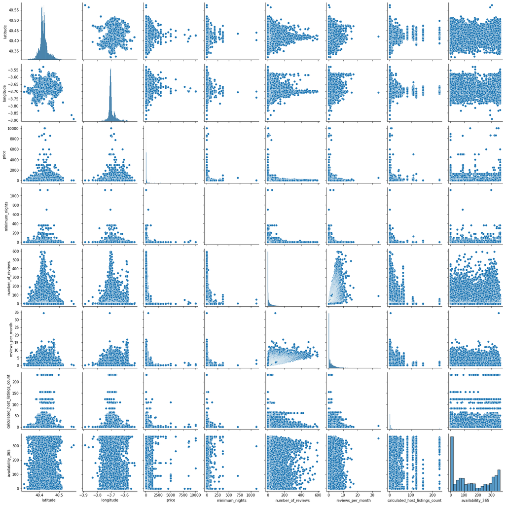

```python
plt.figure(figsize=(10,6))
sns.pairplot(airbnb_num) # nos devuelve los diagramas de dispersión de las relaciones entre variables y los hist de cada variabl
plt.ioff()
```

```
Index(['id', 'name', 'host_id', 'host_name', 'neighbourhood_group',
       'neighbourhood', 'latitude', 'longitude', 'room_type', 'price',
       'minimum_nights', 'number_of_reviews', 'last_review',
       'reviews_per_month', 'calculated_host_listings_count',
       'availability_365'],
      dtype='object')
```

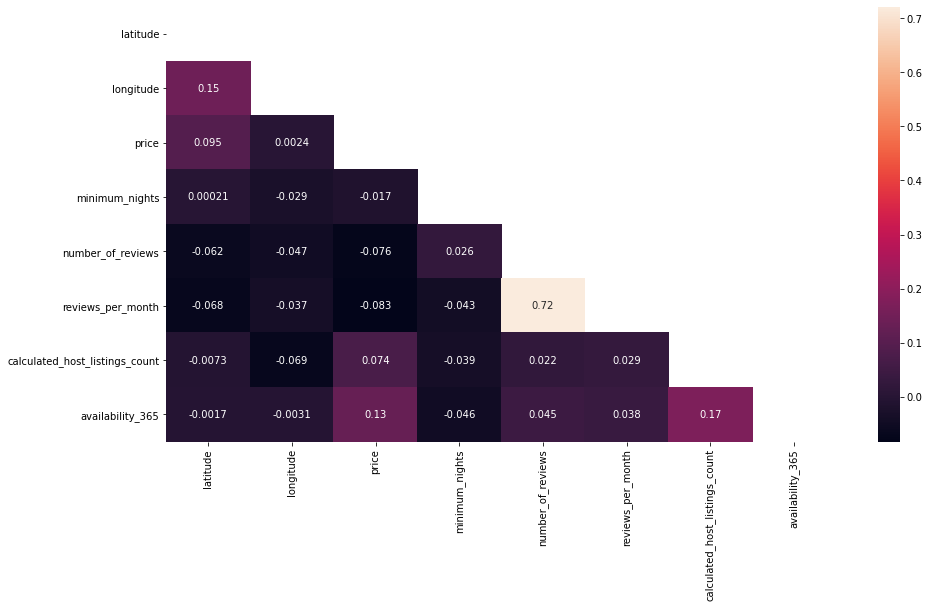

```python
corr = airbnb.corr(method='kendall')
plt.figure(figsize=(15,8))
mask = np.zeros_like(corr)
mask[np.triu_indices_from(mask)] = True # Para que lo muestre triangular
sns.heatmap(corr, annot = True, mask = mask) # que muestre los coeficientes
airbnb.columns
```

Con esta matriz de correlaciones podemos establecer que las correlaciones entre las variables son muy escasas. El mayor coeficiente de correlación existe entre las opiniones por mes y el número total de opiniones de un alojamiento Airbnb.

# Referencias:

- Fuente de datos:
  - https://www.kaggle.com/rusiano/madrid-airbnb-data
- Otras referencias de Kaggle:
  - https://www.kaggle.com/ankit1661/analysis-visualization-and-prediction
  - https://www.kaggle.com/rusiano/housing-crisis-and-tourism-in-madrid
- URL de consultas gráficos
  - https://unipython.com/graficar-analizar-histogramas/
  - https://es.stackoverflow.com/questions/77405/histogramas-con-matplotlib-python-l%C3%ADneas-de-separaci%C3%B3n
  - https://pandas.pydata.org/pandas-docs/
  - https://towardsdatascience.com/visualizing-data-with-pair-plots-in-python-f228cf529166
  - https://seaborn.pydata.org/tutorial/distributions.html
  - https://jakevdp.github.io/PythonDataScienceHandbook/04.08-multiple-subplots.html
- URL de consultas EDA:
  - https://towardsdatascience.com/exploratory-data-analysis-eda-python-87178e35b14
  - https://towardsdatascience.com/exploratory-data-analysis-tutorial-in-python-15602b417445
  - https://www.aprendemachinelearning.com/analisis-exploratorio-de-datos-pandas-python/
  - https://www.kaggle.com/ekami66/detailed-exploratory-data-analysis-with-python
- URL consultas markdown:
  - https://markdown.es/sintaxis-markdown/